# 1.4: Using R Markdown

15 April 2019

## R Markdown

## Writing Reports Using `rmarkdown`

- `rmarkdown` is a cohesive way to
  - Load & tidy data
  - Analyse data, including figures & tables
  - Publish everything in a complete report/analysis
- Everything is one document, with our analysis code embedded alongside our results
- The package `knitr` is the engine behind this

## Writing Reports Using `rmarkdown`

We can output our analysis directly as:

- HTML
- MS Word Documents
- PDF Documents (If you have \(\LaTeX\) installed)
- Slidy or `ioslides` presentations

We never need to use MS Word, Excel or Powerpoint again!

## Writing Reports Using `rmarkdown`

- The file suffix is `.Rmd`
- Include normal text *alongside embedded `R` code.*
- Create all of our figures & tables directly from the data
- Data, experimental and analytic descriptions
- Mathematical/Statistical equations
- Nicely Formatted Results
- Any other information

## Creating an *R* Markdown document

Let's create our first `rmarkdown` document

1. Go to the `File` drop-down menu in RStudio
2. New File -> R Markdown…

## Creating an *R* Markdown document

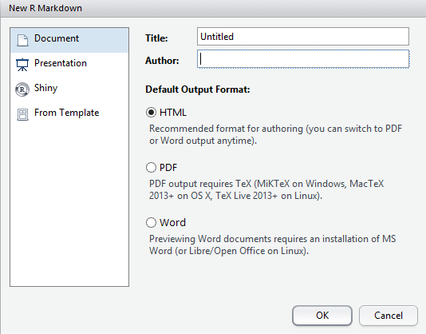

## Creating an *R* Markdown document

1. Change the Title to: My First Report
2. Change the Author to *your own name*
3. Leave everything else as it is & hit OK
4. Save the file as `RMarkdownTutorial.Rmd`

## Looking at the file automatically created

A *header section* is contained between the `---` lines at the top

- **Nothing can be placed before this!**
- Uses YAML (**Y**AML **A**in't **M**arkup **L**anguage)
- Editing is beyond the scope of this course
- Can set custom `.css` files, load LaTeX packages, set parameters etc.

## Looking at the file automatically created

Lines 8 to 10 are a code `chunk`

- Chunks always begin with ```{r}
- Chunks always end with ```
- Executed `R` code goes between these two delineators
- Chunk names are optional and directly follow the `r`
- Other parameters are set here, e.g. do we show/hide the code

## Looking at the file automatically created

Line 12 is a Subsection Heading, starting with `##`

- Click the *staggered text* symbol in the top-right of the Script Window to open the *document outline*
- Chunk names are shown in *italics*
- Section Names in plain text

## Getting Help

Check the help for a guide to the syntax.

`Help > Markdown Quick Reference`

## Compiling The Report

The default format is an `html_document` & we can change this later. Generate the default document by clicking `Knit`

[figure not shown]

## Compiling The Report

The Viewer Pane will appear with the compiled report (probably)

- Note the hyperlink to the RMarkdown website & the bold typeface for the word **Knit**
- The *R* code and the results are printed for `summary(cars)`
- The plot of `temperature` Vs. `pressure` has been embedded
- The code for the plot was hidden using `echo = FALSE`

## Compiling The Report

- We could also export this as an MS Word document by clicking the small 'down' arrow next to the word Knit.
- By default, this will be Read-Only, but can be helpful for sharing with collaborators.
- Saving as a `.PDF` may require an installation of \(\LaTeX\), so we'll ignore that for now.

## Making our own report

Now we can modify the code to create our own analysis.

- Delete everything in your R Markdown file EXCEPT the header
- We'll analyse the `PlantGrowth` dataset which comes with `R`
- First we'll need to describe the data

```r
?PlantGrowth
```

## Rename the report

First we should change the title of the report to something suitable, e.g. *The Effects of Two Herbicide Treatments on Plant Growth*

## Create a "Data Description" Section

Now let's add a section header for our analysis to start the report

1. Type `# Data Description` after the header and after leaving a blank line
2. Use your own words to describe the data

## Create a ``Data Description" Section

My example text:

> Plants were treated with two different herbicides and the effects on growth were compared using the dried weight of the plants after one month. Both treatments were compared to a control group of plants which were not treated with any herbicide. Each group contained 10 plants, giving a total of 30 plants.

## Create a ``Data Description" Section

Hopefully you mentioned that there were 10 plants in each group, with a total of 30.

**Can we get that information from the data itself?**

## Create a ``Data Description" Section

We know that the code `nrow(PlantGrowth)` would give the total number of samples. **We can embed this in our data description!**

1. Instead of the number 30 in your description, enter ``r` `nrow(PlantGrowth)``
2. Compile the HTML document.

## Loading *R* packages

1. Before the Data Description header, add a new header called `Setup`
2. Create a code chunk with the contents `library(tidyverse)`.
3. Recompile the HTML

**Hint: You can create an empty code chunk using** `Ctrl+Alt+I`

This has loaded the `tidyverse` packages for the whole document. All subsequent code chunks can use any functions in the package.

## Loading *R* packages

Notice that this gave us an overly informative message. We can turn this off:

1. After the `r` at the start of the code chunk, add a comma
2. Start typing the word `message` and use the auto-complete feature to set `message = FALSE`
3. Recompile

## Writing the Report

After our description, we could also have a look at the data in a summary. Add the following in a code chunk.

```r
PlantGrowth %>%
  group_by(group) %>%
  summarise(n = n(),
            Mean = mean(weight))
```

(Recompile…)

## Formatting Tables

To change this table into a nicely formatted one:

1. Load `pander` into the workspace
2. Use the function `pander`

In the `Setup` section, on the line after loading `tidyverse` enter:

```r
library(pander)
```

## Formatting Tables

Then head back to the code chunk and add the following.

```r
PlantGrowth %>%
  group_by(group) %>%
  summarise(n = n(),
            Mean = mean(weight)) %>%
  pander(caption = "Sample Sizes and average weights for each group")
```

(Recompile…)

## Using `pander`

The package `pander` is great for formatting `R` output.

Add the following line to your data description:

> "The three groups are classified as ``r` `pander(levels(PlantGrowth$group))``"

(We'll explain this bit of code tomorrow)

## Add a plot of the data

1. Create a plot using `geom_boxplot()`
2. Fill the boxes based on the `group` variable

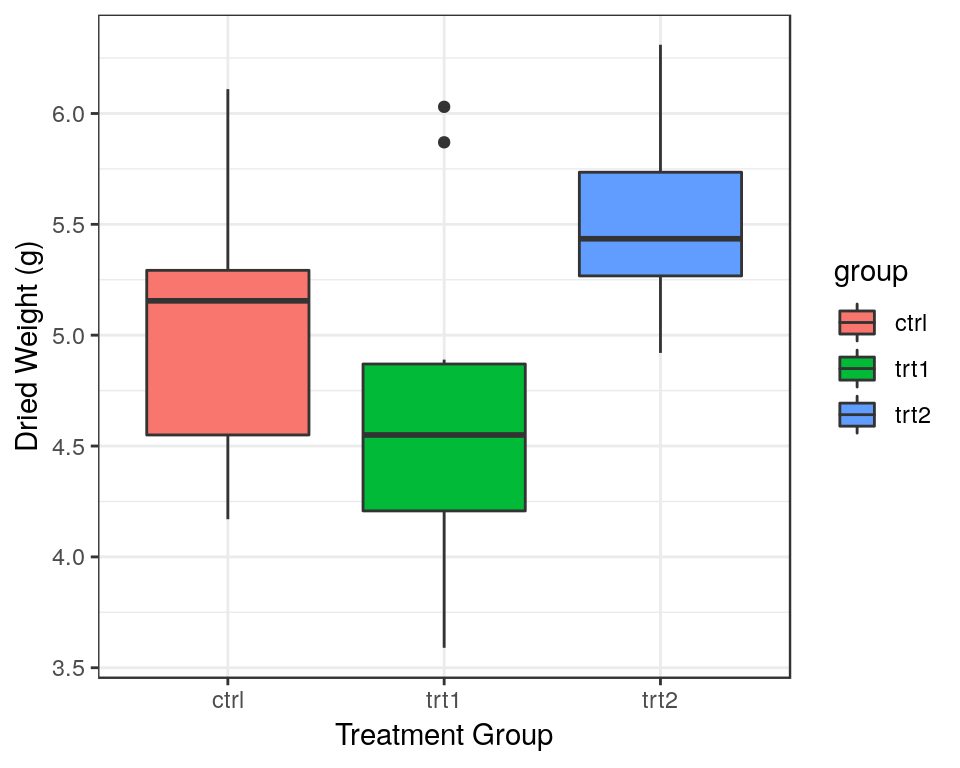

## Analyse the data

Here we can fit a simple linear regression using:

- `weight` as the response variable
- `group` as the predictor variable

To fit a linear model in `R`:

1. Use the function `lm()`
2. Save the results as a new object

## Analyse the data

```r
model_fit <- lm(weight ~ group, data = PlantGrowth)
```

We can view the `summary()` or `anova()` for a given model using

```r
anova(model_fit)
```

```
## Analysis of Variance Table
##
## Response: weight
##           Df  Sum Sq Mean Sq F value  Pr(>F)
## group      2  3.7663  1.8832  4.8461 0.01591 *
## Residuals 27 10.4921  0.3886
## ---
## Signif. codes:  0 '***' 0.001 '**' 0.01 '*' 0.05 '.' 0.1 ' ' 1
```

```r
summary(model_fit)
```

```
##
## Call:
## lm(formula = weight ~ group, data = PlantGrowth)
##
## Residuals:
##     Min      1Q  Median      3Q     Max
## -1.0710 -0.4180 -0.0060  0.2627  1.3690
##
## Coefficients:
##             Estimate Std. Error t value Pr(>|t|)
## (Intercept)   5.0320     0.1971  25.527   <2e-16 ***
## grouptrt1    -0.3710     0.2788  -1.331   0.1944
## grouptrt2     0.4940     0.2788   1.772   0.0877 .
## ---
## Signif. codes:  0 '***' 0.001 '**' 0.01 '*' 0.05 '.' 0.1 ' ' 1
##
## Residual standard error: 0.6234 on 27 degrees of freedom
## Multiple R-squared:  0.2641, Adjusted R-squared:  0.2096
## F-statistic: 4.846 on 2 and 27 DF,  p-value: 0.01591
```

## Analyse the data

To place these as formatted tables in the text we can use `pander()`

```r
model_fit %>% anova() %>% pander()
```

```r
model_fit %>% summary() %>% pander()
```

You can change the default captions if you like

## Add Some Diagnostic Plots

```r
plot(model_fit, which = 1)
plot(model_fit, which = 2)
```

In the chunk header add:  
`echo=FALSE, fig.show='hold', fig.width = 6, fig.cap = "Diagnostic plots for model fit"`

(Try using tab auto-complete to speed that up)

## Finishing the analysis

After you're happy with the way your analysis looks

- A good habit is to finish with a section called `Session Info`
- Add a code chunk which calls the *R* command `sessionInfo()`

So far we've been compiling everything as HTML, but let's switch to an MS Word document. We could email this to our supervisors, or upload to Google docs for collaborators…

## Summary

This basic process is incredibly useful

- We never need to cut & paste anything between R and other documents
- Every piece of information comes directly from our *R* analysis
- We can very easily incorporate new data as it arrives
- Creates *reproducible research*
- Highly compatible with collaborative analysis & version control (Git)

[Home](http://uofabioinformaticshub.github.io/Intro_R_FIB_2019/)